# Python数据处理

## 16. MapReduce和PySpark

主讲人：丁平尖

## 大数据“革命”

- Sloan Digital Sky Survey https://www.sdss.org/
  - 生成的图像如此之多，以至于大多数永远不会被查看...
- 基因组数据：https://en.wikipedia.org/wiki/Genome_project
- 网络爬取
  - 20e9个网页；仅存储页面（不包括图片等）就需要约400TB
- 社交媒体数据
  - Twitter：每天约500e6条推文 YouTube：每分钟上传超过300小时的内容 （这个数字已经是几年前的了）

## 大数据的三个方面

- 体量：TB或PB规模的数据
  - 需要新的处理范式，例如，分布式计算
- 速度：数据以前所未有的速度生成
  - 例如，网络流量数据，Twitter，气候/天气数据
- 多样性：数据以许多不同的格式出现
  - 数据库，但也包括非结构化的文本、音频、视频……混乱的数据需要不同的工具

## MapReduce框架

- 基本思想：
  - 将任务分解为独立的子任务
  - 指定如何将子任务的结果组合成你的答案
- 独立的子任务是一个关键点：
  - 如果我们不断需要共享信息，那么分解任务就是低效的
  - 因为我们将花费更多的时间在通信上，而不是实际计数

## MapReduce的假设

- 任务可以分解成多个部分
- 部分可以并行处理...
- ...进程之间的通信最少。
- 每个部分的结果可以组合以获得答案。

## MapReduce：“大数据”的主力军

- Hadoop、Google MapReduce、Spark等都基于这个框架
  - 指定一个“map”操作，应用于数据集中的每个元素
  - 指定一个“reduce”操作，将列表组合成输出
- 然后我们在多台机器之间分割数据，并组合它们的结果

## MapReduce对你来说并不新鲜

- 你已经知道Map模式：
  - Python：`[f(x) for x in mylist]`
- ...和Reduce模式：
  - Python：`sum([f(x) for x in mylist])（map和reduce）`
- 唯一新的东西是计算模型

## MapReduce

- Map：f(x) = 2x
- Reduce：sum

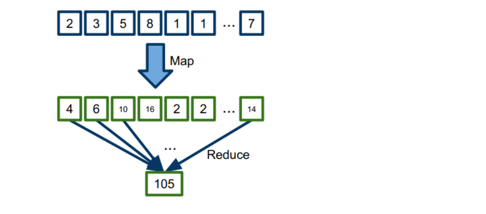

## MapReduce

- Map：f(x) = 2x
- Reduce：sum

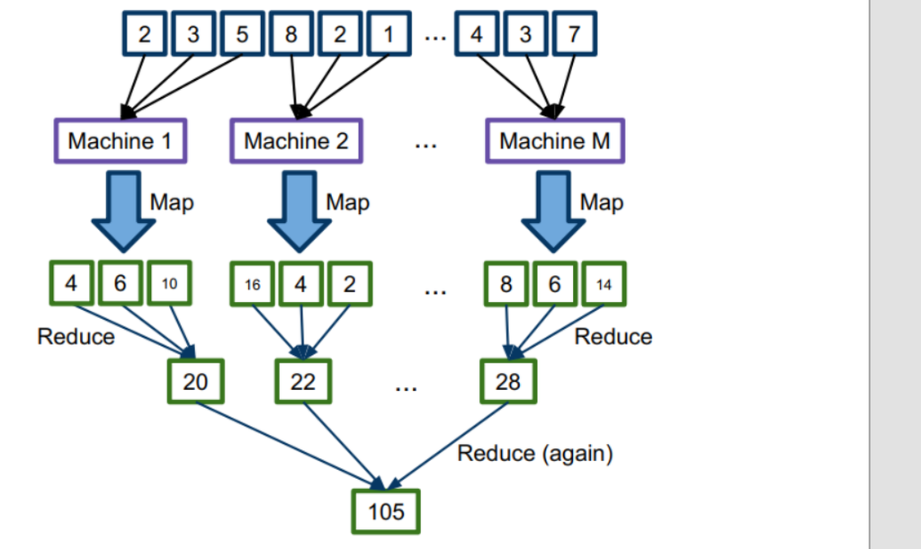

## 词频统计

- 假设我们有一大堆书籍...
  - 例如，Google ngrams：https://books.google.com/ngrams/info
  - ...我们想要计算每个词在集合中出现的次数。
- 分而治之！
  - 1. 每个人都拿一本书，并制作一个(word,count)对的列表。
  - 2. 合并列表，加上具有相同词键的计数。

## MapReduce的基本单位：(key,value) pair

- 例子：
  - 语言数据：<word, count>
  - 入学数据：<student, major>
  - 气候数据：<location, wind speed>
- 在某些环境中，值可以是更复杂的对象
  - 例如，列表，字典，其他数据结构
    - 社交媒体数据：<person, list_of_friends>

## 一个典型的MapReduce程序

- 从文件中读取记录（即，数据片段）
- Map：对于每条记录，提取你关心的信息 以<key,value>对的形式输出这些信息
- Combine：根据它们的键对提取的<key,value>对进行排序和分组
- Reduce：对于每组，汇总，过滤，分组，聚合等，以获得一些新值，v2 将<key, v2>对作为结果文件中的一行输出

## 澄清术语

- MapReduce：最初由Google开发的大规模计算框架
  - 后来通过Apache基金会以Hadoop MapReduce的形式开源
- Apache Hadoop：Apache基金会提供的一套开源工具
  - 包括Hadoop MapReduce、Hadoop HDFS、Hadoop YARN
- Hadoop MapReduce：实现了MapReduce框架
- Hadoop分布式文件系统（HDFS）：分布式文件系统
  - 专为Hadoop MapReduce设计
  - 运行在与MapReduce相同的通用硬件上

## MapReduce：词汇表

- 集群：一组设备（即，计算机）
  - 网络连接以实现快速通信，通常用于分布式计算
  - 由Sun/Oracle grid engine、Slurm、TORQUE或YARN等程序调度作业
- 节点：集群中的单个计算“单元”
  - 大致上，计算机==节点，但每台机器可以有多个节点 通常是通用的（即，非专用的，廉价的）硬件
- 步骤：一个单独的map->combine->reduce“链”
  - 一个步骤不一定包含所有三个map、combine和reduce

## 所以MapReduce让事情变得更简单

- 我们不需要担心分割数据、组织机器之间的通信等，
- 我们只需要指定：
  - Map
  - Combine（可选）
  - Reduce
- Hadoop后端将处理其他所有事情。

## MapReduce中的词频统计：版本1

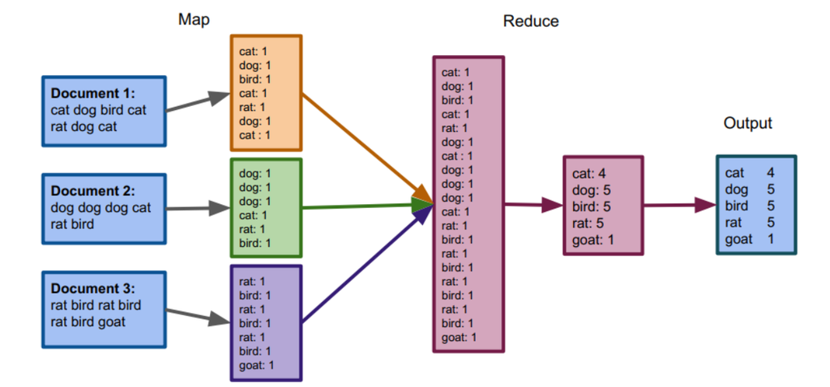

## MapReduce中的词频统计：版本1

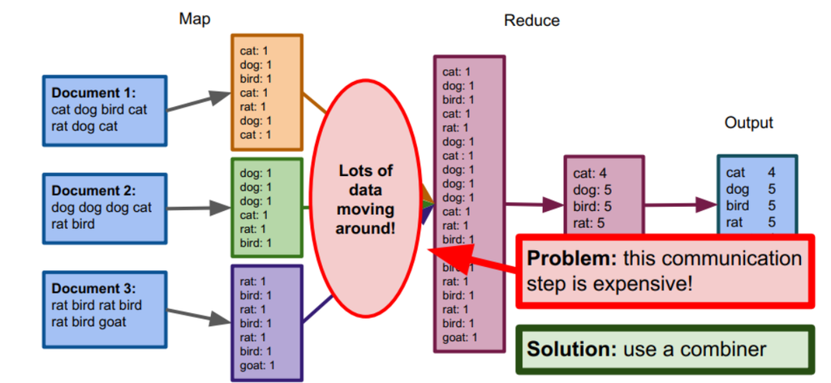

## MapReduce中的词频统计：版本2

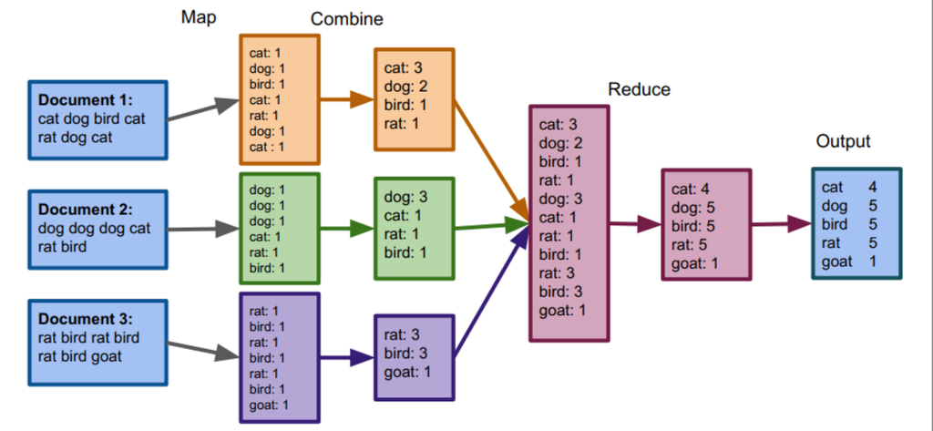

## MapReduce中的词频统计：版本2

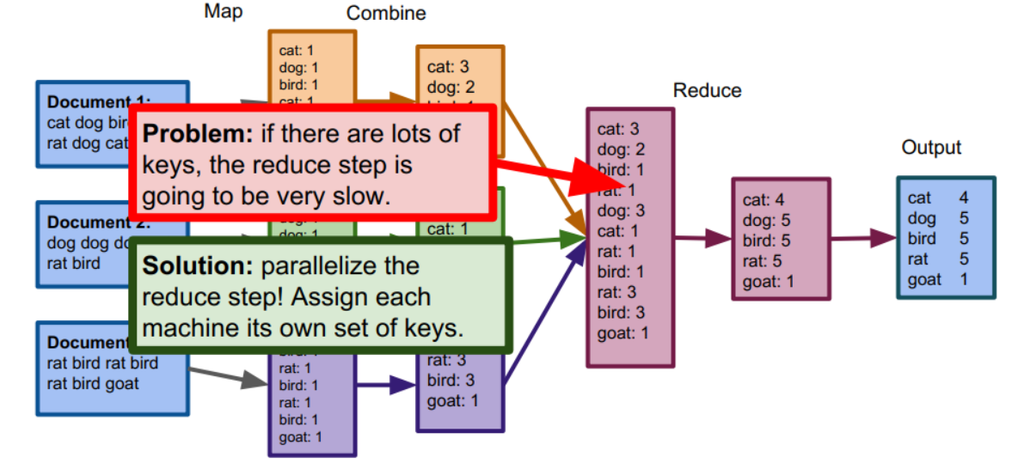

## MapReduce中的词频统计：版本3

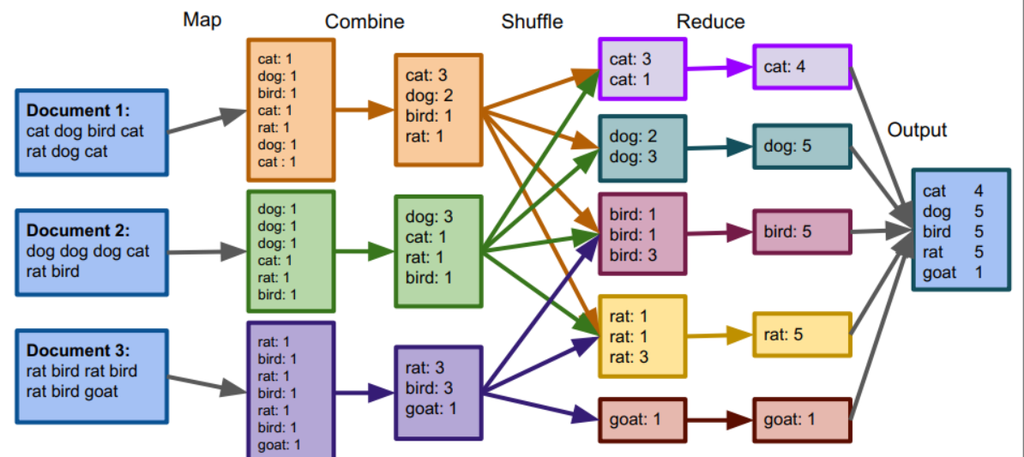

## MapReduce中的词频统计：版本3

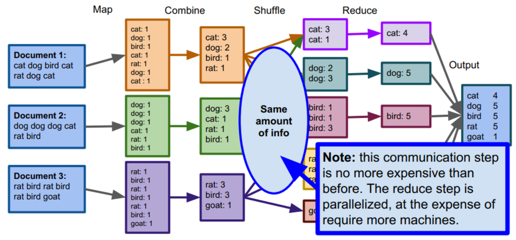

## MapReduce：内部工作机制

- MR作业由以下组成：
  - 一个作业跟踪器或资源管理器节点
  - 一些工作节点
- 资源管理器：
  - 调度和分配任务给工作节点
  - 监控节点，如果工作节点失败则重新调度任务
- 工作节点：
  - 根据资源管理器的指示执行计算
  - 将结果传达给下游节点（例如，Mapper -> Reducer）

## Hadoop分布式文件系统（HDFS）

- Hadoop的存储系统
- 文件系统分布在网络上的多个节点上
  - 与所有文件都在一台计算机上相比
- 容错
  - 文件的多个副本存储在不同的节点上
  - 如果节点失败，仍然可以恢复
- 高吞吐量
  - 许多大文件，可以同时被多个读写者访问

## mrjob Python包

- 安装：pip install mrjob（或conda，或从源代码安装...）
- 可以在没有Hadoop实例的情况下本地运行...
- ...但也可以运行在Hadoop或Spark上

## 使用Apache Spark进行并行计算

- Apache Spark是一个用于大规模并行处理的计算框架
  - 由加州大学伯克利分校AMPLab（现为RISELab）开发，
  - 现在由Apache基金会维护
- 提供Java、Scala和Python的实现
  - 并且这些可以实现交互式运行！

## 为什么使用Spark？

- “等等，Hadoop/mrjob不是已经做了这些事情吗？”
- 简短回答：是的！
- 不那么简短的回答：Spark比Hadoop更快、更灵活
  - 并且由于Spark看起来正在取代Hadoop在行业中的地位
- Spark仍然遵循MapReduce框架，但是更适合于：
  - 交互式会话
  - 缓存（即，数据存储在将要处理它的节点的RAM中，而不是磁盘上）
  - 重复更新计算（例如，随着新数据的到来进行更新）
  - 容错和恢复

## Apache Spark：概览

- 用Scala实现
  - 流行的函数式编程语言（差不多...）
  - 运行在Java虚拟机（JVM）之上 http://www.scala-lang.org/
- 但是可以从Scala、Java和Python调用Spark
- 我们将使用Python进行所有编码
  - PySpark：https://spark.apache.org/docs/0.9.0/python-programming-guide.html
  - 但是你学到的几乎所有东西都可以在其他支持的语言中以最小的变化应用

## 运行Spark

- 选项1：以交互模式运行
  - 在命令行中输入pyspark
  - PySpark提供了一个类似于Python解释器的接口
  - Scala、Java和R也提供了他们自己的交互模式
- 选项2：在集群上运行
  - 编写你的代码，然后通过调度器启动它 spark-submit
  - https://spark.apache.org/docs/latest/submitting-applications.html#launching-applications-with-spark-submit
- 两个基本概念
- SparkContext
  - 对应于连接到Spark集群的对象
    - 在交互模式下自动创建
    - 必须在通过调度器运行时显式创建（我们很快就会看到示例）
  - 维护有关数据存储位置的信息
  - 可以通过提供SparkConf对象进行配置
- 弹性分布式数据集（RDD）
  - 表示一个数据集合
  - 分布式存储在节点上，具有容错能力（与HDFS类似）

## 更多关于RDD的信息

- RDD是Spark的基本单位
  - “分布在集群节点上的元素集合，可以并行操作。”（[https://spark.apache.org/docs/0.9.0/scala-programming-guide.html#overview）](https://spark.apache.org/docs/0.9.0/scala-programming-guide.html#overview%EF%BC%89)
- RDD的元素类似于MapReduce中的<key,value>对
  - RDD大致类似于R中的dataframe
  - RDD元素有点像表中的行
- Spark还可以保持（持久化，在Spark的术语中）
  - RDD在内存中
  - 允许稍后重用或额外处理
- RDD是不可变的，就像Python的元组和字符串一样。

## RDD操作

- 将RDD视为代表数据集
- 两个基本操作：
  - 转换：结果为另一个RDD
    - （例如，map对每个RDD元素应用某个函数）
  - 动作：计算一个值并报告给驱动程序
    - （例如，reduce计算所有元素并计算一些汇总统计量）

## 开发容器（Dev Container）

- 新建文件夹`.devcontainer`
- 新建文件`devcontainer.json`
  - 开发容器（Dev Containers）功能的核心配置文件。它定义了如何设置开发环境，以及如何使用 Docker 或 Docker Compose 来运行该环境。
- 新建文件`docker-compose.yaml`
  - 定义和管理多容器应用。对于开发容器来说，它通常用来协调多个服务（例如数据库、缓存服务、应用服务）或扩展基础容器配置。
- 新建文件`Dockerfile`
  - Docker 的核心文件，用来定义一个单独的容器镜像。它描述了如何构建环境，包括基础镜像、依赖安装、环境配置等。

```python
!cat .devcontainer/devcontainer.json
```

```
{
	"name": "PySpark local cluster",
	"dockerComposeFile": ["./docker-compose.yaml"],
    "service": "spark",
    "workspaceFolder": "/home/jovyan/code",

    "customizations": {
        "vscode" : {
            "settings": {
                "terminal.integrated.profiles.linux": {
                    "bash": {
                        "path": "/bin/bash"
                    }
                },
                "terminal.integrated.defaultProfile.linux": "bash",
                "python.linting.enabled": true,
                "python.linting.pylintEnabled": true
            },
            "extensions": [
                "ms-python.python",
		        "ms-toolsai.jupyter"
            ]
        }
    }
}
```

```python
!cat .devcontainer/docker-compose.yaml
```

```
version: '3'
services:
  spark:
    build:
      context: .
      dockerfile: Dockerfile
    volumes:
      - ..:/home/jovyan/code
    ports:
      - "8888:8888"
    command: start.sh jupyter notebook --NotebookApp.token='' --NotebookApp.disable_check_xsrf=true --NotebookApp.allow_origin='*' --NotebookApp.ip='0.0.0.0'
```

```python
!cat .devcontainer/Dockerfile
```

```
# Choose your desired base image
FROM jupyter/pyspark-notebook:latest

# name your environment and choose the python version
ARG conda_env=vscode_pyspark
ARG py_ver=3.11

# you can add additional libraries you want mamba to install by listing them below the first line and ending with "&& \"
RUN mamba create --yes -p "${CONDA_DIR}/envs/${conda_env}" python=${py_ver} ipython ipykernel && \
    mamba clean --all -f -y

# alternatively, you can comment out the lines above and uncomment those below
# if you'd prefer to use a YAML file present in the docker build context

# COPY --chown=${NB_UID}:${NB_GID} environment.yml "/home/${NB_USER}/tmp/"
# RUN cd "/home/${NB_USER}/tmp/" && \
#     mamba env create -p "${CONDA_DIR}/envs/${conda_env}" -f environment.yml && \
#     mamba clean --all -f -y

# create Python kernel and link it to jupyter
RUN "${CONDA_DIR}/envs/${conda_env}/bin/python" -m ipykernel install --user --name="${conda_env}" && \
    fix-permissions "${CONDA_DIR}" && \
    fix-permissions "/home/${NB_USER}"

# any additional pip installs can be added by uncommenting the following line
RUN "${CONDA_DIR}/envs/${conda_env}/bin/pip" install pyspark pandas --no-cache-dir

# if you want this environment to be the default one, uncomment the following line:
RUN echo "conda activate ${conda_env}" >> "${HOME}/.bashrc"
```